# Statistics for quantitative mass spectrometry - Day 1

Section 1 : MSstats, introductioin to data and preprocessing

Meena Choi

5/8/2017

# Objective

- Preprocessing steps to make required input format for MSstats from output from diverse output of spectral processing tools.
- Make annotation file, based on experimental design.

# Data

- the quantified peak intensities data from ABRF 2015, processed by Skyline.

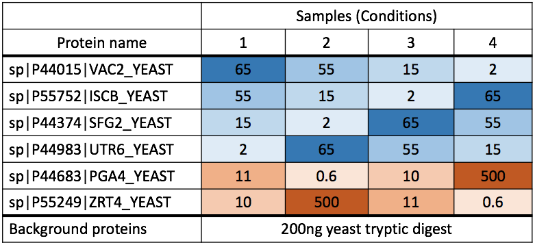

Summary of the ABRF 2015 study design, Choi, et al. J Proteome Res. 2017

# 1. Load MSstats

Load MSstats first. Then you are ready to start MSstats.

```r
library(MSstats)
?MSstats
```

# 2. Allowable data formats

`MSstats` performs statistical analysis steps, that follow peak identification and quantitation. Therefore, input to MSstats is the output of other software tools (such as `Skyline`, `MaxQuant` and so on) that read raw spectral files , identify and quantify spectral peaks. The preferred structure of data for use in MSstats is a .csv file in a *long* format with at least 10 columns representing the following variables: **ProteinName**, **PeptideSequence**, **PrecursorCharge**, **FragmentIon**, **ProductCharge**, **IsotopeLabelType**, **Condition**, **BioReplicate**, **Run**, **Intensity**. The variable names are fixed, but are case-insensitive.

```
##   ProteinName PeptideSequence PrecursorCharge FragmentIon ProductCharge
## 1      bovine     S.PVDIDTK_5               5          NA            NA
## 2      bovine     S.PVDIDTK_5               5          NA            NA
## 3      bovine     S.PVDIDTK_5               5          NA            NA
## 4      bovine     S.PVDIDTK_5               5          NA            NA
## 5      bovine     S.PVDIDTK_5               5          NA            NA
## 6      bovine     S.PVDIDTK_5               5          NA            NA
##   IsotopeLabelType Condition BioReplicate Run Intensity
## 1                L        C1            1   1   2636792
## 2                L        C1            1   2   1992418
## 3                L        C1            1   3   1982146
## 4                L        C2            1   4   5019594
## 5                L        C2            1   5   4560468
## 6                L        C2            1   6   3627849
```

Let’s start preprocessing steps to make required input format for MSstats from output from diverse output of spectral processing tools.

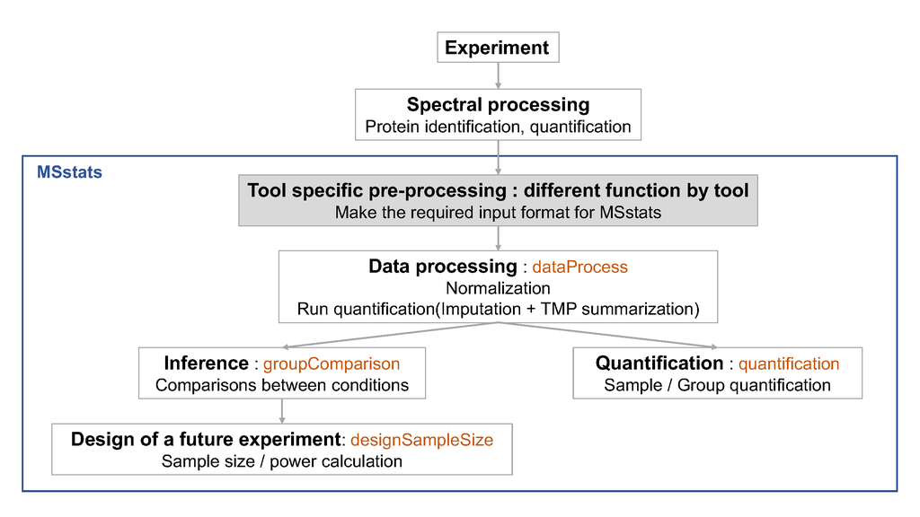

# 3. Skyline output

## 3.1 Read data

The required input data is generated automatically when using `MSstats` report format in `Skyline`. We first load and access the dataset processed by `Skyline`. The name of saved file from `Skyline` using `MSstats report format` is *‘ABRF2015_Skyline_report.csv’*. or you can use the published data from this link (https://panoramaweb.org/labkey/project/MacCoss/brendan/manuscripts/iPRG%202015/begin.view). This example dataset is the exactly same data in ‘iPRG_10ppm_2rt_15cut_nosingle.csv’ from the link above.

```r
# Read output from skyline
raw.skyline <- read.csv(file="data_Skyline/ABRF2015_Skyline_report.csv")
```

```r
# Check the first 6 rows of dataset
head(raw.skyline)
```

```
##                   ProteinName PeptideSequence PeptideModifiedSequence
## 1 DECOY_sp|P0CF18|YM085_YEAST      KDMYGNPFQK         KDM[+16]YGNPFQK
## 2 DECOY_sp|P0CF18|YM085_YEAST      KDMYGNPFQK         KDM[+16]YGNPFQK
## 3 DECOY_sp|P0CF18|YM085_YEAST      KDMYGNPFQK         KDM[+16]YGNPFQK
## 4 DECOY_sp|P0CF18|YM085_YEAST      KDMYGNPFQK         KDM[+16]YGNPFQK
## 5 DECOY_sp|P0CF18|YM085_YEAST      KDMYGNPFQK         KDM[+16]YGNPFQK
## 6 DECOY_sp|P0CF18|YM085_YEAST      KDMYGNPFQK         KDM[+16]YGNPFQK
##   PrecursorCharge PrecursorMz FragmentIon ProductCharge ProductMz
## 1               3    415.1974   precursor             3  415.1974
## 2               3    415.1974   precursor             3  415.1974
## 3               3    415.1974   precursor             3  415.1974
## 4               3    415.1974   precursor             3  415.1974
## 5               3    415.1974   precursor             3  415.1974
## 6               3    415.1974   precursor             3  415.1974
##   IsotopeLabelType Condition BioReplicate                  FileName
## 1            light        NA           NA JD_06232014_sample1_B.raw
## 2            light        NA           NA JD_06232014_sample1_C.raw
## 3            light        NA           NA JD_06232014_sample1-A.raw
## 4            light        NA           NA JD_06232014_sample2_A.raw
## 5            light        NA           NA JD_06232014_sample2_B.raw
## 6            light        NA           NA JD_06232014_sample2_C.raw
##      Area StandardType Truncated annotation_QValue
## 1  147327           NA     False                NA
## 2 1373397           NA     False                NA
## 3   71765           NA     False                NA
## 4   66387           NA     False                NA
## 5  107736           NA     False                NA
## 6  380812           NA     False                NA
```

There are some column named differently than required input. The information for `Condition` and `BioReplicate` is missing. Let’s do preliminary check for this input.

```r
# total number of unique protein name
length(unique(raw.skyline$Protein))
```

```
## [1] 3097
```

```r
# several isotopic peaks for peptide charge
unique(raw.skyline$FragmentIon)
```

```
## [1] precursor       precursor [M+1] precursor [M+2]
## Levels: precursor precursor [M+1] precursor [M+2]
```

```r
# unique FileName, which is MS run.
unique(raw.skyline$FileName)
```

```
##  [1] JD_06232014_sample1_B.raw JD_06232014_sample1_C.raw
##  [3] JD_06232014_sample1-A.raw JD_06232014_sample2_A.raw
##  [5] JD_06232014_sample2_B.raw JD_06232014_sample2_C.raw
##  [7] JD_06232014_sample3_A.raw JD_06232014_sample3_B.raw
##  [9] JD_06232014_sample3_C.raw JD_06232014_sample4_B.raw
## [11] JD_06232014_sample4_C.raw JD_06232014_sample4-A.raw
## 12 Levels: JD_06232014_sample1_B.raw ... JD_06232014_sample4-A.raw
```

```r
# 'Truncated' column
unique(raw.skyline$Truncated)
```

```
## [1] False       True
## Levels:  False True
```

```r
# count table for 'Truncated' column
xtabs(~Truncated, raw.skyline)
```

```
## Truncated
##           False    True
##     237 1256666     829
```

```r
# count which 'Truncated' is 'True'
sum(raw.skyline$Truncated == 'True')
```

```
## [1] 829
```

## 3.2. Set annotation file

Annotation information is required to fill in **Condition** and **BioReplicate** for corresponding **Run** information. Users have to prepare as csv or txt file like ‘ABRF2015_Skyline_annotation.csv’, which includes **Run**, **Condition**, and **BioReplicate** information, and load it in R.

```r
annot.skyline <- read.csv(file="data_Skyline/ABRF2015_Skyline_annotation.csv")
annot.skyline
```

```
##                          Run  Condition BioReplicate
## 1  JD_06232014_sample1-A.raw Condition1            1
## 2  JD_06232014_sample2_A.raw Condition2            2
## 3  JD_06232014_sample4_B.raw Condition4            4
## 4  JD_06232014_sample1_B.raw Condition1            1
## 5  JD_06232014_sample1_C.raw Condition1            1
## 6  JD_06232014_sample2_B.raw Condition2            2
## 7  JD_06232014_sample2_C.raw Condition2            2
## 8  JD_06232014_sample3_A.raw Condition3            3
## 9  JD_06232014_sample3_B.raw Condition3            3
## 10 JD_06232014_sample3_C.raw Condition3            3
## 11 JD_06232014_sample4-A.raw Condition4            4
## 12 JD_06232014_sample4_C.raw Condition4            4
```

### 3.2.1 Common mistake for annotation file : Incorrect Run information

Let’s check whether **Run** information is same as **File.Name** in output of `Skyline`.

```r
setdiff(unique(raw.skyline$FileName), annot.skyline$Run)
```

```
## character(0)
```

```r
setdiff(annot.skyline$Run, unique(raw.skyline$FileName))
```

```
## character(0)
```

There is no issue in this annotation.

Let’s try the example with unmatched information.

```r
annot.wrong <- read.csv(file="data_Skyline/ABRF2015_Skyline_annotation_wrong_example.csv")
annot.wrong
```

```
##                          Run  Condition BioReplicate
## 1  JD_06232014_sample1_A.raw Condition1            1
## 2  JD_06232014_sample2_A.raw Condition2            2
## 3  JD_06232014_sample4_B.raw Condition4            4
## 4  JD_06232014_sample1_B.raw Condition1            1
## 5  JD_06232014_sample1_C.raw Condition1            1
## 6  JD_06232014_sample2_B.raw Condition2            2
## 7  JD_06232014_sample2_C.raw Condition2            2
## 8  JD_06232014_sample3_A.raw Condition3            3
## 9  JD_06232014_sample3_B.raw Condition3            3
## 10 JD_06232014_sample3_C.raw Condition3            3
## 11 JD_06232014_sample4-A.raw Condition4            4
## 12 JD_06232014_sample4_C.raw Condition4            4
```

### 3.2.2 Common mistake for annotation file : Incorrect `BioReplicate` information

`MSstats` distinguish the design of experiment as group comparison, time course, paired design, with the combination of `Condition`, `BioReplicate`, and `Run`.

#### Group comparison

In a group comparison design, the conditions (e.g., disease states) are profiled across **non-overlapping sets of biological replicates (i.e., subjects)**. In this example there are 2 conditions, Disease and Control (in general the number of conditions can vary). There are 3 subjects (i.e., biological replicates) per condition (in general an equal number of replicates per condition is not required). Each subject has 2 technical replicate runs (in general technical replicates are not required, and their number per sample may vary). Overall, in this example there are 2 × 3 × 2 = 12 mass spectrometry runs.

| `Condition` | `BioReplicate` | `Run` |
| --- | --- | --- |
| Disease | Subject1 | 1 |
| Disease | Subject1 | 2 |
| Disease | Subject2 | 3 |
| Disease | Subject2 | 4 |
| Disease | Subject3 | 5 |
| Disease | Subject3 | 6 |
| Control | Subject4 | 7 |
| Control | Subject4 | 8 |
| Control | Subject5 | 9 |
| Control | Subject5 | 10 |
| Control | Subject6 | 11 |
| Control | Subject6 | 12 |

The most important is that 1) subject IDs for disease group are completely different thatn subject IDs for control group 2) `Run` is not order of spectral acquisition, but just unique MS run ID.

#### Time course

The important feature of a time course experimental design is that **a same subject (i.e., biological replicate) is repetitively measured across multiple time points**. In this example there are 2 time points, Time1 and Time2 (in general the number of times can vary). There are 4 subjects (i.e., biological replicates) measured across times (in general an equal number of times per replicate is not required). There are no technical replicates (in general the number of technical replicates per sample may vary). Overall, in this example there are 2 × 4 × 1 = 8 mass spectrometry runs.

| `Condition` | `BioReplicate` | `Run` |
| --- | --- | --- |
| Time1 | Subject1 | 1 |
| Time2 | Subject1 | 2 |
| Time1 | Subject2 | 3 |
| Time2 | Subject2 | 4 |
| Time1 | Subject3 | 5 |
| Time2 | Subject3 | 6 |
| Time1 | Subject4 | 7 |
| Time2 | Subject4 | 8 |

#### Paired design

Another frequently used experimental design is a *paired design*, where measurements from **multiple conditions (such as healthy biopsy and disease biopsy) are taken from a same subject**. The statistical model for this experimental design is the same as in the time course experiment, however the values in the columns of the input data may have a different appearence. In this example there are 2 subjects, PatientA and PatientB (in general the number of patients can vary). There are two conditions per subject, BiopsyHealthy and BiopsyTumor (in general the number of conditions per subject can exceed two). In this example there are 3 technical replicates of each type (in this example, the technical replicates are biopsies; in general these can also be replicate sample preparations or replicate mass spectrometry runs). Overall, in this example there are $2 \times 2 \times 3 = 12$ mass spectrometry runs.

| `Condition` | `BioReplicate` | `Run` |
| --- | --- | --- |
| BiopsyHealthy | PatientA | 1 |
| BiopsyHealthy | PatientA | 2 |
| BiopsyHealthy | PatientA | 3 |
| BiopsyTumor | PatientA | 4 |
| BiopsyTumor | PatientA | 5 |
| BiopsyTumor | PatientA | 6 |
| BiopsyHealthy | PatientB | 7 |
| BiopsyHealthy | PatientB | 8 |
| BiopsyHealthy | PatientB | 9 |
| BiopsyTumor | PatientB | 10 |
| BiopsyTumor | PatientB | 11 |
| BiopsyTumor | PatientB | 12 |

## 3.3. Preprocessing with `SkylinetoMSstatsFormat`

The input data for `MSstats` is required to contain variables of **ProteinName**, **PeptideSequence**, **PrecursorCharge**, **FragmentIon**, **ProductCharge**, **IsotopeLabelType**, **Condition**, **BioReplicate**, **Run**, **Intensity**. These variable names should be fixed. `MSstats` input from Skyline adapts the column scheme of the dataset so that it fits `MSstats` input format. However there are several extra column names and also some of them need to be changed. `SkylinetoMSstatsFormat` function helps pre-processing for making right format of MSstats input from Skyline output. For example, it renames some column name, and replace truncated peak intensities with NA. Another important step is to handle isotopic peaks before using `dataProcess`. The output from Skyline for DDA experiment has several measurements of peak area from the monoisotopic, M+1 and M+2 peaks. To get a robust measure of peptide intensity, we can sum over isotopic peaks per peptide or use the highest peak. Here we take a summation per peptide ion.

Here is the summary of pre-processing steps in `SkylinetoMSstatsFormat` function (in orange box below).

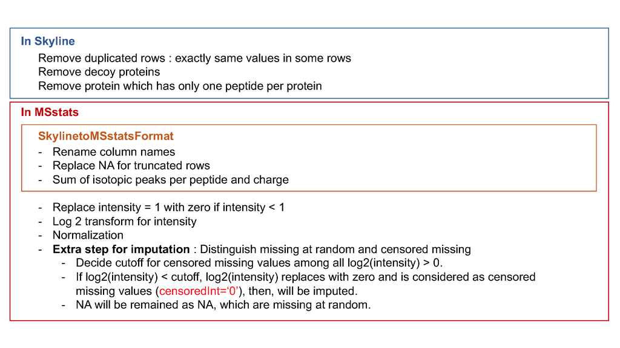

For further details, visit the help file using the following code.

```r
?SkylinetoMSstatsFormat
```

```r
# reformating and pre-processing for Skyline output.
input.skyline <- SkylinetoMSstatsFormat(raw.skyline, annotation=annot.skyline)
```

```
## ** Proteins, which names include DECOY, are removed.
```

```
## Peptides, that are used in more than one proteins, are removed.
```

```
## ** Truncated peaks are replaced with NA.
```

```
## ** For DDA datasets, three isotopic peaks per feature and run are summed.
```

```r
head(input.skyline)
```

```
##            ProteinName         PeptideSequence PrecursorCharge FragmentIon
## 1 sp|P38915|SPT8_YEAST      AAAAGAGGAGDSGDAVTK               2         sum
## 2 sp|P40457|MLP2_YEAST              QLLDESSEQK               2         sum
## 3 sp|P42943|TCPH_YEAST            GGAEQVIAEVER               2         sum
## 4 sp|P40202|CCS1_YEAST              DYSFLGVIAR               2         sum
## 5 sp|Q12049|THP3_YEAST LSWNNVNQVSNPLMVTPLPGLQK               3         sum
## 6 sp|P47122|NPA3_YEAST          TPPYVINLDPAVLR               3         sum
##   ProductCharge IsotopeLabelType  Condition BioReplicate
## 1            NA                L Condition1            1
## 2            NA                L Condition1            1
## 3            NA                L Condition1            1
## 4            NA                L Condition1            1
## 5            NA                L Condition1            1
## 6            NA                L Condition1            1
##                         Run Intensity
## 1 JD_06232014_sample1_B.raw         0
## 2 JD_06232014_sample1_B.raw   6686797
## 3 JD_06232014_sample1_B.raw 284344776
## 4 JD_06232014_sample1_B.raw 200172818
## 5 JD_06232014_sample1_B.raw   2841395
## 6 JD_06232014_sample1_B.raw   5602300
```

## 3.4 Preliminary check

```r
length(unique(input.skyline$ProteinName))
```

```
## [1] 3027
```

```r
sum(is.na(input.skyline$Intensity))
```

```
## [1] 233
```

```r
sum(!is.na(input.skyline$Intensity) & input.skyline$Intensity==0)
```

```
## [1] 2585
```

# 4. MaxQuant output

## 4.1 Read data

Three files should be prepared before MSstats. Two files, ‘proteinGroups.txt’ and ‘evidence.txt’ are outputs from MaxQuant.

```r
# First, get protein ID information
proteinGroups <- read.table("data_MaxQuant/proteinGroups.txt", sep = "\t", header = TRUE)
```

```r
# 3. Read in MaxQuant file: evidence.txt
evi <- read.table("data_MaxQuant/evidence.txt", sep="\t", header=TRUE)
colnames(evi)
```

```
##  [1] "Sequence"
##  [2] "Length"
##  [3] "Modifications"
##  [4] "Modified.sequence"
##  [5] "Oxidation..M..Probabilities"
##  [6] "Oxidation..M..Score.Diffs"
##  [7] "Acetyl..Protein.N.term."
##  [8] "Oxidation..M."
##  [9] "Missed.cleavages"
## [10] "Proteins"
## [11] "Leading.proteins"
## [12] "Leading.razor.protein"
## [13] "Gene.names"
## [14] "Protein.names"
## [15] "Type"
```

[output cut: 46 more lines]

```r
unique(evi$Raw.file)
```

```
##  [1] JD_06232014_sample1-A JD_06232014_sample2_A JD_06232014_sample4_B
##  [4] JD_06232014_sample1_B JD_06232014_sample1_C JD_06232014_sample2_B
##  [7] JD_06232014_sample2_C JD_06232014_sample3_A JD_06232014_sample3_B
## [10] JD_06232014_sample3_C JD_06232014_sample4-A JD_06232014_sample4_C
## 12 Levels: JD_06232014_sample1_B ... JD_06232014_sample4-A
```

## 4.2 Set annotation file

Annotation information is required to fill in **Condition** and **BioReplicate** for corresponding **Raw.file** information. Users have to prepare as csv or txt file like ‘ABRF2015_MaxQuant_annotation.csv’, which includes **Raw.file**, **Condition**, and **BioReplicate** information, and load it in R. **Raw.file** column in the annotation file should be the same as unique **Raw.file** in evidence.txt file.

```r
# Read in annotation including condition and biological replicates: annotation.csv
annot.maxquant <- read.csv("data_MaxQuant/ABRF2015_MaxQuant_annotation.csv", header = TRUE)
annot.maxquant
```

```
##                 Raw.file  Condition BioReplicate IsotopeLabelType
## 1  JD_06232014_sample1-A Condition1            1                L
## 2  JD_06232014_sample2_A Condition2            2                L
## 3  JD_06232014_sample4_B Condition4            4                L
## 4  JD_06232014_sample1_B Condition1            1                L
## 5  JD_06232014_sample1_C Condition1            1                L
## 6  JD_06232014_sample2_B Condition2            2                L
## 7  JD_06232014_sample2_C Condition2            2                L
## 8  JD_06232014_sample3_A Condition3            3                L
## 9  JD_06232014_sample3_B Condition3            3                L
## 10 JD_06232014_sample3_C Condition3            3                L
## 11 JD_06232014_sample4-A Condition4            4                L
## 12 JD_06232014_sample4_C Condition4            4                L
```

## 4.3 Preprocessing with `MaxQtoMSstatsFormat`

`MaxQtoMSstatsFormat` function helps pre-processing for making right format of MSstats input from MaxQuant output. Basically, this function gets peptide ion intensity from `‘evidence.txt’` file. In addition, there are several steps to filter out or to modify the data in order to get required information.

Here is the summary of pre-processing steps in `MaxQtoMSstatsFormat` function (in orange box below).

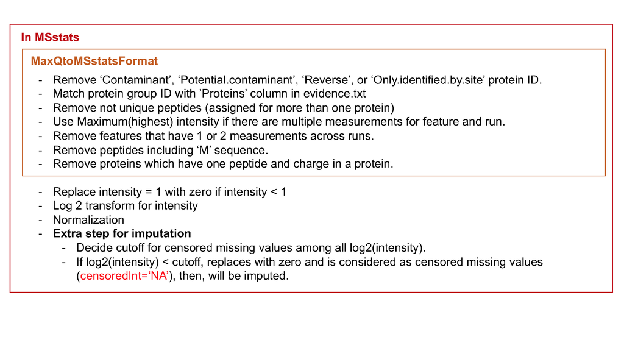

```r
?MaxQtoMSstatsFormat
```

```r
# reformating and pre-processing for MaxQuant output.
# no protein with 1 peptide
input.maxquant <- MaxQtoMSstatsFormat(evidence=evi,
                                      annotation=annot.maxquant,
                                      proteinGroups=proteinGroups,
                                      removeProtein_with1Peptide=TRUE)
```

```
## ** + Contaminant, + Reverse, + Only.identified.by.site, proteins are removed.
```

```
## ** Peptide and charge, that have 1 or 2 measurements across runs, are removed.
```

```
## ** 282 proteins, which have only peptide and charge in a protein, are removed among 3157 proteins.
```

```r
head(input.maxquant)
```

```
##   ProteinName        PeptideSequence PrecursorCharge FragmentIon
## 1      D6VTK4 EGEVEPVDMYTPDTAADEEARK               3          NA
## 2      D6VTK4    FYPGTLSSFQTDSINNDAK               2          NA
## 3      D6VTK4             IGPFADASYK               2          NA
## 4      D6VTK4          NQFYQLPTPTSSK               2          NA
## 5      D6VTK4           TFVSETADDIEK               2          NA
## 6      D6VTK4         TNTITSDFTTSTDR               2          NA
##   ProductCharge IsotopeLabelType  Condition BioReplicate
## 1            NA                L Condition1            1
## 2            NA                L Condition1            1
## 3            NA                L Condition1            1
## 4            NA                L Condition1            1
## 5            NA                L Condition1            1
## 6            NA                L Condition1            1
##                     Run Intensity
## 1 JD_06232014_sample1_B  87141000
## 2 JD_06232014_sample1_B  46167000
## 3 JD_06232014_sample1_B  45425000
## 4 JD_06232014_sample1_B  47094000
## 5 JD_06232014_sample1_B        NA
## 6 JD_06232014_sample1_B  62786000
```

## 4.4 Preliminary check

```r
length(unique(input.maxquant$ProteinName))
```

```
## [1] 2875
```

```r
sum(is.na(input.maxquant$Intensity))
```

```
## [1] 40056
```

```r
sum(!is.na(input.maxquant$Intensity) & input.maxquant$Intensity==0)
```

```
## [1] 0
```

### Challenge

> - Let’s check unique information for `Run`,`BioReplicate` and `Condition` in `input.maxquant`.

```r
unique(input.maxquant[, c('Run', 'BioReplicate', 'Condition')])
```

```
##                          Run BioReplicate  Condition
## 1      JD_06232014_sample1_B            1 Condition1
## 30600  JD_06232014_sample1_C            1 Condition1
## 61199  JD_06232014_sample1-A            1 Condition1
## 91798  JD_06232014_sample2_A            2 Condition2
## 122397 JD_06232014_sample2_B            2 Condition2
## 152996 JD_06232014_sample2_C            2 Condition2
## 183595 JD_06232014_sample3_A            3 Condition3
## 214194 JD_06232014_sample3_B            3 Condition3
## 244793 JD_06232014_sample3_C            3 Condition3
## 275392 JD_06232014_sample4_B            4 Condition4
## 305991 JD_06232014_sample4_C            4 Condition4
## 336590 JD_06232014_sample4-A            4 Condition4
```

# 5. Progenesis output

## 5.1. Read data

```r
# First, read output of Progenesis
raw.progenesis <- read.csv("data_Progenesis/ABRF2015_Progenesis_raw.csv", stringsAsFactors=F) # the data file
head(raw.progenesis)
```

```
##       X                  X.1    X.2              X.3              X.4
## 1
## 2     # Retention time (min) Charge              m/z    Measured mass
## 3    16     52.5563333333333      2 501.781277638303 1001.54800234285
## 4    32             38.15255      2 474.251481407549 946.488409881339
## 5 11167     36.2224333333333      2  474.25154745893 946.488541984099
## 6    41              45.5598      2 371.731536419815 741.448519905869
##                    X.5               X.6    X.7       X.8           X.9
## 1
## 2       Mass error (u)  Mass error (ppm)  Score  Sequence Modifications
## 3 -0.00255665715405939 -2.55269904358308      1 TANDVLTIR
## 4 -0.00219111866147159 -2.31499251990099      1 VTDGVMVAR
## 5  -0.0020590159006133 -2.17542139186367      1 VTDGVMVAR
## 6 -0.00120309413080122 -1.62262402086192 0.9996   AGLNIVR
##                    X.10
```

[output cut: 111 more lines]

One file is for annotation information, required to fill in Condition and BioReplicate for corresponding Run information. Users have to prepare as csv or txt file like ‘ABRF2015_Progenesis_annotation.csv’, which includes **Run**, **Condition**, and **BioReplicate** information, and load it in R.

## 5.2. Set annotation file

Annotation information is required to fill in **Condition** and **BioReplicate** for corresponding **Run** information. Users have to prepare as csv or txt file like ‘ABRF2015_Progenesis_annotation.csv’, which includes **Run**, **Condition**, and **BioReplicate** information, and load it in R.

```r
## Read in annotation including condition and biological replicates: ABRF2015_Progenesis_annotation.csv
annot.progenesis <- read.csv("data_Progenesis/ABRF2015_Progenesis_annotation.csv", header = TRUE)
annot.progenesis
```

```
##                      Run  Condition BioReplicate
## 1  JD_06232014_sample1-A Condition1            1
## 2  JD_06232014_sample2_A Condition2            2
## 3  JD_06232014_sample4_B Condition4            4
## 4  JD_06232014_sample1_B Condition1            1
## 5  JD_06232014_sample1_C Condition1            1
## 6  JD_06232014_sample2_B Condition2            2
## 7  JD_06232014_sample2_C Condition2            2
## 8  JD_06232014_sample3_A Condition3            3
## 9  JD_06232014_sample3_B Condition3            3
## 10 JD_06232014_sample3_C Condition3            3
## 11 JD_06232014_sample4-A Condition4            4
## 12 JD_06232014_sample4_C Condition4            4
```

!! `Run` information should be the same as annotated in output of `Progenesis`.

## 5.3. Preprocessing with `ProgenesistoMSstatsFormat`

The output from `Progenesis` includes peptide ion-level quantification for each MS runs. `ProgenesistoMSstatsFormat` function helps pre-processing for making right format of `MSstats` input from `Progenesis` output. Basically, this function reformats wide format to long format. It provide **Raw.abundance**, **Normalized.abundance** and **Spectral count** columns. This converter uses **Raw.abundance** columns for Intensity values. In addition, there are several steps to filter out or to modify the data in order to get required information. Here is the summary of pre-processing steps in `ProgenesistoMSstatsFormat` function (in orange box below).

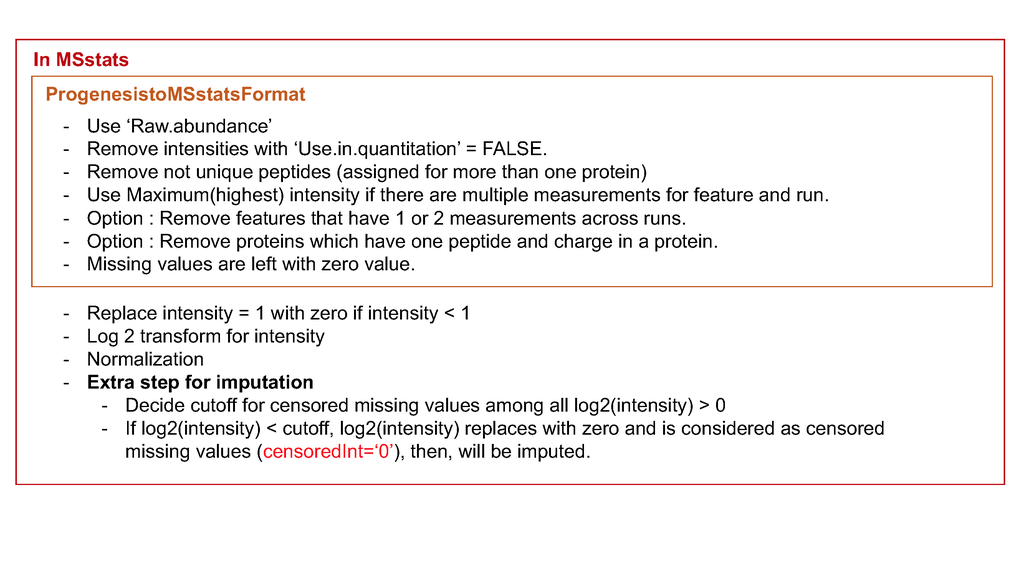

```r
?ProgenesistoMSstatsFormat
```

```r
# reformating and pre-processing for Progenesis output.
input.progenesis <- ProgenesistoMSstatsFormat(raw.progenesis,
                                              annotation=annot.progenesis,
                                              removeProtein_with1Peptide=TRUE)
```

```
## ** Peptides, that are used in more than one proteins, are removed.
```

```
## ** Multiple measurements in a feature and a run are summarized by summaryforMultipleRows.
```

```
## ** 898 proteins, which have only one feature in a protein, are removed among 3913 proteins.
```

```r
## now 'input.progenesis' is ready for MSstats
head(input.progenesis)
```

```
##             ProteinName       PeptideModifiedSequence PrecursorCharge
## 1 sp|A5Z2X5|YP010_YEAST              LTGNPELSSLDEVLAK               2
## 2 sp|A5Z2X5|YP010_YEAST RPAQLLL[N-term] nTerm+42.0106               2
## 3  sp|D6VTK4|STE2_YEAST        EGEVEPVDMYTPDTAADEEARK               3
## 4  sp|D6VTK4|STE2_YEAST           FYPGTLSSFQTDSINNDAK               2
## 5  sp|D6VTK4|STE2_YEAST                    IGPFADASYK               2
## 6  sp|O13297|CET1_YEAST                   IAGNAVGSVVK               2
##   FragmentIon ProductCharge IsotopeLabelType  Condition BioReplicate
## 1          NA            NA                L Condition1            1
## 2          NA            NA                L Condition1            1
## 3          NA            NA                L Condition1            1
## 4          NA            NA                L Condition1            1
## 5          NA            NA                L Condition1            1
## 6          NA            NA                L Condition1            1
##                     Run Intensity
## 1 JD_06232014_sample1_B 2550357.3
## 2 JD_06232014_sample1_B  865491.8
## 3 JD_06232014_sample1_B 3767734.3
## 4 JD_06232014_sample1_B 2591735.2
## 5 JD_06232014_sample1_B 2301483.1
## 6 JD_06232014_sample1_B  415181.8
```

## 5.5. Preliminary check for preprocessed data

```r
length(unique(input.progenesis$ProteinName))
```

```
## [1] 3015
```

```r
sum(is.na(input.progenesis$Intensity))
```

```
## [1] 0
```

```r
sum(!is.na(input.progenesis$Intensity) & input.progenesis$Intensity==0)
```

```
## [1] 418
```

```r
table(input.progenesis$Run)
```

[output not shown]

### Challenge

> - Let’s check unique information for `Run`,`BioReplicate` and `Condition`.

```r
unique(input.progenesis[, c('Run', 'BioReplicate', 'Condition')])
```

```
##                          Run BioReplicate  Condition
## 1      JD_06232014_sample1_B            1 Condition1
## 10547  JD_06232014_sample1_C            1 Condition1
## 21093  JD_06232014_sample1-A            1 Condition1
## 31639  JD_06232014_sample2_A            2 Condition2
## 42185  JD_06232014_sample2_B            2 Condition2
## 52731  JD_06232014_sample2_C            2 Condition2
## 63277  JD_06232014_sample3_A            3 Condition3
## 73823  JD_06232014_sample3_B            3 Condition3
## 84369  JD_06232014_sample3_C            3 Condition3
## 94915  JD_06232014_sample4_B            4 Condition4
## 105461 JD_06232014_sample4_C            4 Condition4
## 116007 JD_06232014_sample4-A            4 Condition4
```

# 6. Spectronaut output

## 6.1 Read data

We first load and access the dataset processed by `Spectronaut`.

```r
# Read output from skyline : Bruderer2015.SN10.xls
raw.SN <- read.csv("data_SN/Bruderer2015.SN10.xls", sep="\t")
```

```r
head(raw.SN)
```

```
##    R.Condition                      R.FileName R.Replicate
## 1 SGSDSsample1 B_D140314_SGSDSsample1_R01_MHRM           1
## 2 SGSDSsample1 B_D140314_SGSDSsample1_R01_MHRM           1
## 3 SGSDSsample1 B_D140314_SGSDSsample1_R01_MHRM           1
## 4 SGSDSsample1 B_D140314_SGSDSsample1_R01_MHRM           1
## 5 SGSDSsample1 B_D140314_SGSDSsample1_R01_MHRM           1
## 6 SGSDSsample1 B_D140314_SGSDSsample1_R01_MHRM           1
##   PG.ProteinAccessions PG.ProteinGroups PG.Quantity PEP.GroupingKey
## 1               A0AVT1           A0AVT1    13667.06       VVQTDETAR
## 2               A0AVT1           A0AVT1    13667.06       VVQTDETAR
## 3               A0AVT1           A0AVT1    13667.06       VVQTDETAR
## 4               A0AVT1           A0AVT1    13667.06       VVQTDETAR
## 5               A0AVT1           A0AVT1    13667.06       VVQTDETAR
## 6               A0AVT1           A0AVT1    13667.06       VVQTDETAR
##   PEP.StrippedSequence PEP.Quantity EG.iRTPredicted
```

[output cut: 41 more lines]

## 6.2 Preprocessing with `SpectronauttoMSstatsFormat`

The input data for MSstats is required to contain variables of **ProteinName**, **PeptideSequence**, **PrecursorCharge**, **FragmentIon**, **ProductCharge**, **IsotopeLabelType**, **Condition**, **BioReplicate**, **Run**, **Intensity**. These variable names should be fixed. Therefore, we need to get subset of useful columns and to rename them. Also several filtering steps are required. `SpectronauttoMSstatsFormat` function helps pre-processing for making right format of `MSstats` input from `Spectronaut` output. First, it uses only noloss from **F.FrgLossType**. If not, multiple measurements for each feature and run can be happend. `Spectronaut` provides the column named **F.ExcludedFromQuantification** based on XIC quality such as interference between chromatographies. Only features with **F.ExcludedFromQuantification == ‘False’** should be used. **PG.ProteinGroups** is used for **ProteinName**. **EG.ModifiedSequence** is used for **PeptideSequence**. **FG.Charge** is used for **PrecursorCharge**. **F.FrgIon** is used for **FragmentIon**. **F.Charge** is used for **ProductCharge**. **F.PeakArea** with default option is used for **Intensity**. Then several filtering steps will be performed. Here is the summary of pre-processing steps for SWATH/DIA experiment in `SpectronauttoMSstatsFormat` function (in orange box below).

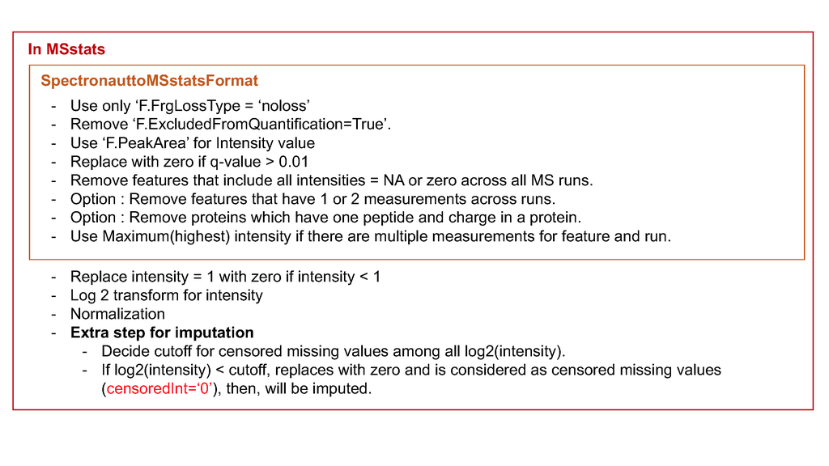

`SpectronauttoMSstatsFormat` function helps pre-processing for making right format of `MSstats` input from `Spectronaut` output. Basically, this function gets `MSstats` format output from `Spectronaut`. In addition, there are several steps to filter out or to modify the data in order to get required information.

```r
?SpectronauttoMSstatsFormat
```

```r
# reformating and pre-processing for Spectronaut output.
input.SN <- SpectronauttoMSstatsFormat(raw.SN)
```

```
## ** Intensities with great than 0.01 in EG.Qvalue are replaced with zero.
```

```
## ** All peptides are unique peptides in proteins.
```

```
## ** No multiple measurements in a feature and a run.
```

```r
head(input.SN)
```

```
##    ProteinName         PeptideSequence PrecursorCharge FragmentIon
## 1       A0AVT1             _VVQTDETAR_               2          y7
## 6       A0AVT1             _VVQTDETAR_               2          y5
## 10      A0AVT1          _LATSISETLEEK_               2          y8
## 11      A0AVT1          _LATSISETLEEK_               2          y4
## 13      A0AVT1 _VC[+57]PTTETIYNDEFYTK_               2          y8
## 14      A0AVT1 _VC[+57]PTTETIYNDEFYTK_               2         y14
##    ProductCharge    Condition                             Run BioReplicate
## 1              1 SGSDSsample1 B_D140314_SGSDSsample1_R01_MHRM            1
## 6              1 SGSDSsample1 B_D140314_SGSDSsample1_R01_MHRM            1
## 10             1 SGSDSsample1 B_D140314_SGSDSsample1_R01_MHRM            1
## 11             1 SGSDSsample1 B_D140314_SGSDSsample1_R01_MHRM            1
## 13             1 SGSDSsample1 B_D140314_SGSDSsample1_R01_MHRM            1
## 14             2 SGSDSsample1 B_D140314_SGSDSsample1_R01_MHRM            1
##     Intensity IsotopeLabelType
## 1  15882.3604                L
## 6   3084.8518                L
## 10   182.7725                L
## 11   667.2112                L
## 13  2555.1445                L
## 14  1747.8701                L
```

## 5.5. Preliminary check for preprocessed data

```r
length(unique(input.SN$ProteinName))
```

```
## [1] 3335
```

```r
sum(is.na(input.SN$Intensity))
```

```
## [1] 13
```

```r
sum(!is.na(input.SN$Intensity) & input.SN$Intensity==0)
```

```
## [1] 19664
```

# 7. Save your work

We can save the data that we made so far.

```r
save(input.skyline, file='./data_Skyline/input.skyline.rda')
save(input.maxquant, file='./data_MaxQuant/input.maxquant.rda')
save(input.progenesis, file='./data_Progenesis/input.progenesis.rda')
save(input.SN, file='./data_SN/input.SN.rda')
```